# matplotlibについて

## (オプション) ヒストグラムの作成

- ヒストグラムはデータの分布(ばらつき)を確認するための可視化方法

### データ読み込み

```python
import pandas as pd

# ファイルの指定
xlsxfile  = "dataset/iris.xlsx" # dataset内のExcelファイル
# Googleドライブの場合は次のコメントアウトを外す
# xlsxfile = "drive/My Drive/Colab Notebooks/第04回_プログラム/"+xlsxfile

# データの読み込み
df_iris = pd.read_excel(xlsxfile, sheet_name='iris')

# setosa抽出
TrueFalse = df_iris["species"] == "setosa"         # setosaの行の真偽を判定
df_setosa = df_iris[TrueFalse]                     # True（真）の行を抽出
display(df_setosa.head(3))                         # 先頭3行を表示

# がくの長さ(sepal_length)抽出
x1 = df_setosa["sepal_length"]                     # がくの長さ
```

|  | sepal_length | sepal_width | petal_length | petal_width | species |
| --- | --- | --- | --- | --- | --- |
| 0 | 5.1 | 3.5 | 1.4 | 0.2 | setosa |
| 1 | 4.9 | 3.0 | 1.4 | 0.2 | setosa |
| 2 | 4.7 | 3.2 | 1.3 | 0.2 | setosa |

### ヒストグラム作成（装飾なし）

- 適した階級数を**自動で設定**してくれる

  ```
  plt.hist(x, ec="色")
  ```

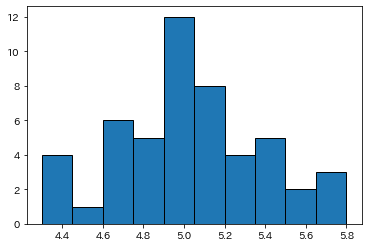

```python
import matplotlib.pyplot as plt # グラフ作成のためにインポート
import japanize_matplotlib      # グラフで日本語を使用するためにインポート
%matplotlib inline

# グラフ作成
plt.hist(x1, ec="black") # バー（bar）に黒枠を入れる場合

# グラフ表示
plt.show()
```

上記のヒストグラムでは階級数が10と設定された

### 階級（データ区間）で設定

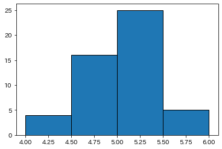

```python
import matplotlib.pyplot as plt # グラフ作成のためにインポート
import japanize_matplotlib      # グラフで日本語を使用するためにインポート
%matplotlib inline

# 階級をリストで設定
list_bins = [4.0, 4.5, 5.0, 5.5, 6.0]

# グラフ作成
plt.hist(x1, ec="black", bins=list_bins) # グラフ生成

# グラフ表示
plt.show()
```

### ヒストグラムの集計結果の取得

- 作成されたヒストグラムの集計値は、`plt.hist()`の戻り値で取得する
- 次のように３つの変数名で戻り値を受け取ることが多い
  - `n, bins, patches = plt.hist(x)`
  - `n`: 各区間のデータの個数（度数）
  - `bins`: データ区間の境界値のリスト（階級）
  - `patches`: ヒストグラムのバーを表すオブジェクトのリスト（特に使用しない)

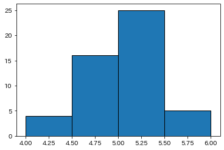

```
階級 [4.  4.5 5.  5.5 6. ]
頻度 [ 4. 16. 25.  5.]
```

```python
import matplotlib.pyplot as plt # グラフ作成のためにインポート
import japanize_matplotlib      # グラフで日本語を使用するためにインポート
%matplotlib inline

# 階級をリストで設定
list_bins = [4.0, 4.5, 5.0, 5.5, 6.0]

# グラフ作成
n, bins, patches = plt.hist(x1, ec="black", bins=list_bins) # グラフ生成

# グラフ表示
plt.show()

print("階級", bins)
print("頻度", n)
```

### レポート用のグラフ作成のためのオプション設定

- 今回は以下を設定(散布図と同様)
  - グラフサイズの変更（グラフ作成前に記述）: `plt.figure(figure=(横インチ, 縦インチ))`
  - タイトル名追加とフォントサイズ変更: `plt.title(タイトル名, fontsize=値)`
  - x軸のラベル名追加とフォントサイズ変更: `plt.xlabel(ラベル名, fontsize=値)`
  - y軸のラベル名追加とフォントサイズ変更: `plt.ylabel(ラベル名, fontsize=値)`
  - x軸の目盛のフォントサイズ変更: `plt.xticks(fontsize=値)`
  - y軸の目盛フォントサイズ変更: `plt.yticks(fontsize=値)`
  - 横方向の補助線追加: `plt.grid(axis="y")`
  - グラフの画像を保存: `plt.savefig("ファイル名", , bbox_inches="tight")`

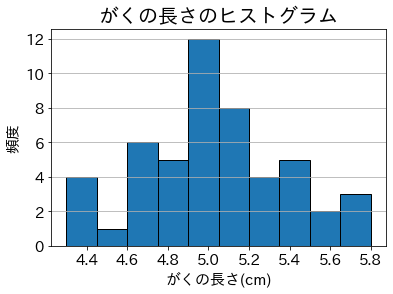

```python
import matplotlib.pyplot as plt # グラフ作成のためにインポート
import japanize_matplotlib      # グラフで日本語を使用するためにインポート
%matplotlib inline

# グラフ作成
plt.hist(x1, ec="black")

# 追加オプション
plt.title("がくの長さのヒストグラム", fontsize=20) # タイトルを追加（フォントサイズ指定）
plt.xlabel("がくの長さ(cm)", fontsize=15) # x軸のラベルを追加（フォントサイズ指定）
plt.ylabel("頻度",  fontsize=15)  # y軸のラベルを追加（フォントサイズ指定）
plt.xticks(fontsize=15)  # x軸の目盛のフォントサイズ変更
plt.yticks(fontsize=15)  # y軸の目盛のフォントサイズ変更
plt.grid(axis="y")

# 出力設定
pngfile  = "グラフ_ヒストグラム_がくの長さ.png" # グラフ画像のファイル名
# Googleドライブの場合は次のコメントアウトを外す
# pngfile = "drive/My Drive/Colab Notebooks/第04回_プログラム/"+pngfile
plt.savefig(pngfile, bbox_inches='tight') # 画像の保存

# グラフ表示
plt.show()
```

### 練習

テストの点数に関するヒストグラムを作成してみよう。

(1) datasetの5教科成績.xlsxからデータを使用する。`5教科成績`シートのデータを`df_score`のデータフレームを読み込もう。

(2)上記の「レポート用のグラフ作成のためのオプション設定」を参考にして、国語の点数のヒストグラムを作成してみよう。

- 国語の点数は、変数`a`に代入してグラフ作成に使用するものとする
- タイトルと軸のラベルを入れる
- グラフのフォントサイズを調整する（タイトルは20ポイント、xラベル、yラベル、目盛は15ポイントとする）
- 階級を0-10, 10-20, 20-30, 30-40, 40-50, 50-60, 60-70, 70-80, 80-90, 90-100と設定
- 横方向の補助線を入れる
- グラフの画像を「グラフ_ヒストグラム_国語.png」という名前を保存する
- `階級`および`頻度`を表示する

解答例

```python
# (1)
import pandas as pd

# ファイルの指定
xlsxfile  = "dataset/5教科成績.xlsx" # dataset内のExcelファイル
# Googleドライブの場合は次のコメントアウトを外す
# xlsxfile = "drive/My Drive/Colab Notebooks/第04回_プログラム/"+xlsxfile

# データの読み込み
df_score = pd.read_excel(xlsxfile, sheet_name='5教科成績')

# データの表示
display(df_score)
```

|  | クラス | 国語 | 英語 | 社会 | 数学 | 理科 |
| --- | --- | --- | --- | --- | --- | --- |
| 0 | A | 30 | 20 | 43 | 51 | 63 |
| 1 | A | 39 | 16 | 21 | 49 | 56 |
| 2 | A | 29 | 6 | 30 | 23 | 57 |
| 3 | A | 95 | 87 | 87 | 77 | 100 |
| 4 | A | 70 | 44 | 71 | 78 | 67 |
| ... | ... | ... | ... | ... | ... | ... |
| 161 | E | 82 | 90 | 78 | 80 | 88 |
| 162 | E | 0 | 1 | 8 | 2 | 9 |
| 163 | E | 45 | 27 | 26 | 29 | 24 |
| 164 | E | 73 | 56 | 31 | 43 | 32 |
| 165 | E | 60 | 85 | 85 | 89 | 80 |

166 rows × 6 columns

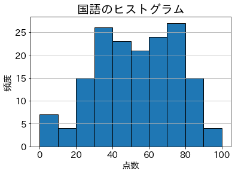

```
階級 [  0  10  20  30  40  50  60  70  80  90 100]
頻度 [ 7.  4. 15. 26. 23. 21. 24. 27. 15.  4.]
```

```python
# (2)
# 使用する列（項目）の抽出
a = df_score["国語"]

# 階級をリストで設定
list_bins = [0, 10, 20, 30, 40, 50, 60, 70, 80, 90, 100]

# グラフ作成
n, bins, patches = plt.hist(a, ec="black", bins=list_bins)

# 追加オプション
plt.title("国語のヒストグラム", fontsize=20) # タイトルを追加（フォントサイズ指定）
plt.xlabel("点数", fontsize=15) # x軸のラベルを追加（フォントサイズ指定）
plt.ylabel("頻度",  fontsize=15)  # y軸のラベルを追加（フォントサイズ指定）
plt.xticks(fontsize=15)  # x軸の目盛のフォントサイズ変更
plt.yticks(fontsize=15)  # y軸の目盛のフォントサイズ変更
plt.grid(axis="y")

# 出力設定
pngfile  = "グラフ_ヒストグラム_国語.png" # グラフ画像のファイル名
# Googleドライブの場合は次のコメントアウトを外す
# pngfile = "drive/My Drive/Colab Notebooks/第04回_プログラム/"+pngfile
plt.savefig(pngfile, bbox_inches='tight') # 画像の保存

# グラフ表示
plt.show()

# 階級と頻度を表示
print("階級", bins)
print("頻度", n)
```